# STAT 4410/8416 Homework 1

ISLAM MD TAHIDUL

Due on Sep 21

1. Based on your reading assignments answer the following questions: —
1. What is data science?
- **Answer**: Data science is an interdisciplinary field that deals with the extraction of knowledge, insights, and meaningful information from large and complex datasets. It combines various techniques from statistics, mathematics, computer science, and domain-specific knowledge to analyze data, uncover patterns, make predictions, and support decision-making.
2. Explain with an example what you mean by data product.
- **Answer**:A data product is a software application or service that relies on data to provide valuable insights, predictions, or functionality. Consider a fitness tracker as an example. When you wear a fitness tracker, it collects various data points such as your heart rate, the number of steps you take, and the quality of your sleep. This data is processed by the tracker’s algorithms.  
  The output is not just raw data; it’s transformed into meaningful information. For instance, the fitness tracker can provide you with insights on your daily activity levels, recommend exercise routines based on your goals, and track your progress over time through charts and graphs.  
  The tracker becomes a data product because it uses data as its core resource to offer valuable features and benefits to the user, helping them make healthier lifestyle choices. It’s a tool that empowers users with insights they wouldn’t have without the data processing capabilities of the device. Data products are prevalent in various fields, from healthcare to finance, harnessing data to deliver practical solutions and enhance decision-making.
  3. Carefully read Cleveland’s paper shown in lecture 2 and discuss what he suggested about the field of statistics and data science.
- **Answer**:The seminal article “Data Science: An Action Plan for Expanding the Technical Areas of the Field of Statistics” published in 2001, William S. Cleveland advocated for the emergence of data science as a distinct and interdisciplinary field. He recognized the profound impact of the digital age on the volume and complexity of data, emphasizing that traditional statistical methods alone were inadequate for handling this data deluge.  
  Cleveland defined data science as a field focused on developing new techniques and tools for extracting meaningful knowledge and insights from data. He underscored the importance of data exploration, visualization, and computational skills in this endeavor, suggesting that visual representation of data is essential for comprehension and decision-making.  
  Moreover, he stressed that data science should produce actionable insights with real-world applications. Collaborative efforts between statisticians, computer scientists, domain experts, and data visualization specialists were encouraged to tackle complex problems effectively.  
  Cleveland’s vision also included education and ethical considerations. He called for educational programs to equip individuals with the necessary skills for data science roles and emphasized ethical responsibilities regarding data privacy and usage.  
  His article was a seminal contribution that laid the foundation for the evolution of data science as a multifaceted field, bridging statistical expertise, computational proficiency, and domain-specific knowledge to address the challenges and opportunities presented by the data-rich environment of the 21st century.
4. Explain in a short paragraph how data science is different from computer science.
- **Answer**:Data science and computer science are closely related but distinct fields. Computer science primarily focuses on the design, development, and optimization of computer systems, algorithms, and software. It deals with programming, software engineering, and the theoretical aspects of computation. In contrast, data science is more concerned with leveraging data to extract meaningful insights, make predictions, and solve real-world problems. It involves statistical analysis, machine learning, data visualization, and domain expertise to understand and interpret data. While computer science provides the technical foundation for data science, data science is broader in scope, encompassing the entire data lifecycle from collection to analysis and decision-making.
5. What is data literacy? Is it important to be data literate in this modern world? Explain why or why not.
- **Answer**: Data literacy: Data literacy is the ability to read, interpret, and communicate with data effectively.

  Importants to be data literate:
  - It empowers informed decision-making in personal life and business.
  - Data literacy fosters critical thinking and helps distinguish credible information from fake news.
  - It opens up career opportunities in data-related fields.
  - Essential for understanding and managing personal finances.
  - Crucial for navigating data privacy concerns in the digital age.
  - Becomes increasingly indispensable in our data-driven world.
6. In his article, Donoho talked about the Common Task Framework. Explain what it is and why he mentioned it.
- **Answer**:In his article “50 Years of Data Science,” David Donoho discusses the Common Task Framework as a key concept in the field of data science. The Common Task Framework refers to the practice of evaluating and comparing different data analysis and machine learning methods using standardized tasks or challenges.

```r
# Step 1:Loading the Required Libraries
library(ggplot2)
# Step 2:Loading the Data
tips_data <- read.csv("http://www.ggobi.org/book/data/tips.csv")

#Step 3:Inspect the Data

# View the first few rows of the dataset
head(tips_data)
```

```
##   obs totbill  tip sex smoker day  time size
## 1   1   16.99 1.01   F     No Sun Night    2
## 2   2   10.34 1.66   M     No Sun Night    3
## 3   3   21.01 3.50   M     No Sun Night    3
## 4   4   23.68 3.31   M     No Sun Night    2
## 5   5   24.59 3.61   F     No Sun Night    4
## 6   6   25.29 4.71   M     No Sun Night    4
```

```r
# View the last few rows of the dataset
tail(tips_data)
```

```
##     obs totbill  tip sex smoker day  time size
## 239 239   35.83 4.67   F     No Sat Night    3
## 240 240   29.03 5.92   M     No Sat Night    3
## 241 241   27.18 2.00   F    Yes Sat Night    2
## 242 242   22.67 2.00   M    Yes Sat Night    2
## 243 243   17.82 1.75   M     No Sat Night    2
## 244 244   18.78 3.00   F     No Thu Night    2
```

```r
# Get an overview of the dataset's structure
str(tips_data)
```

```
## 'data.frame':    244 obs. of  8 variables:
##  $ obs    : int  1 2 3 4 5 6 7 8 9 10 ...
##  $ totbill: num  17 10.3 21 23.7 24.6 ...
##  $ tip    : num  1.01 1.66 3.5 3.31 3.61 4.71 2 3.12 1.96 3.23 ...
##  $ sex    : chr  "F" "M" "M" "M" ...
##  $ smoker : chr  "No" "No" "No" "No" ...
##  $ day    : chr  "Sun" "Sun" "Sun" "Sun" ...
##  $ time   : chr  "Night" "Night" "Night" "Night" ...
##  $ size   : int  2 3 3 2 4 4 2 4 2 2 ...
```

```r
# Generate summary statistics
summary(tips_data)
```

```
##       obs            totbill           tip             sex
##  Min.   :  1.00   Min.   : 3.07   Min.   : 1.000   Length:244
##  1st Qu.: 61.75   1st Qu.:13.35   1st Qu.: 2.000   Class :character
##  Median :122.50   Median :17.80   Median : 2.900   Mode  :character
##  Mean   :122.50   Mean   :19.79   Mean   : 2.998
##  3rd Qu.:183.25   3rd Qu.:24.13   3rd Qu.: 3.562
##  Max.   :244.00   Max.   :50.81   Max.   :10.000
##     smoker              day                time                size
##  Length:244         Length:244         Length:244         Min.   :1.00
##  Class :character   Class :character   Class :character   1st Qu.:2.00
##  Mode  :character   Mode  :character   Mode  :character   Median :2.00
##                                                           Mean   :2.57
##                                                           3rd Qu.:3.00
##                                                           Max.   :6.00
```

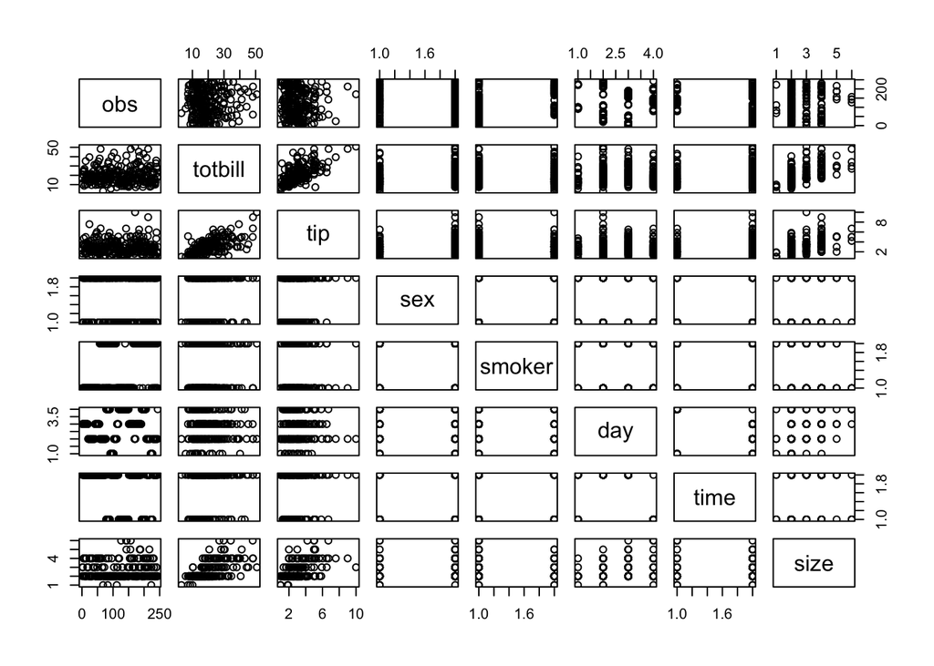

```r
#Plot
plot(tips_data)
```

3. In our **R** class, we learned about recursive functions that produce a sequence of numbers up to a given number, say $n$, as demonstrated with the following code:

```r
foo <- function(x) {
  print(x)
  if(x > 1) {
    foo(x - 1)
  }
}

moo <- function(x) {
  if(x > 1) {
    moo(x - 1)
  }
  print(x)
}

foo(3)
```

```
## [1] 3
## [1] 2
## [1] 1
```

```r
moo(3)
```

```
## [1] 1
## [1] 2
## [1] 3
```

Explain why `moo()` prints 1 through 3 while `foo()` prints from 3 to 1.

- **Answer**:The difference in the order of printed values between the foo() and moo() functions is due to the placement of the print(x) statement within the functions and the sequence of recursive calls.
  - In the foo() function, the print(x) statement is the first action, so it prints the current value of x and then calls itself with a decremented x. This leads to a decrementing sequence of values being printed, from 3 to 1.
  - In contrast, in the moo() function, the recursive call happens before the print(x) statement. So, the function calls itself with a decremented x first, creating a stack of recursive calls. When the base case is reached (x <= 1), the print(x) statement is executed, resulting in values being printed in an increasing order, from 1 to 3, as the function unwinds the stack.
4. The function `sqrt()` provides the square root of a non-negative number. Note what happens when you try `sqrt(-1)`. We want to create our own function that either finds the square root of a non-negative number or provides a custom message if we pass it a negative number.

```r
#our own function
custom_sqrt <- function(x) {
  if (x < 0) {
    return("Cannot compute square root of a negative number")
  } else {
    return(sqrt(x))
  }
}

# Testing the custom_sqrt function
custom_sqrt(9)   # Returns the square root of 9 that is (3)
```

```
## [1] 3
```

```r
custom_sqrt(-4)  # Returns the custom message
```

```
## [1] "Cannot compute square root of a negative number"
```

1. Create a new `R` function `getRootNotVectorized()` that will return the square root of any non-negative number and ‘not possible’ for a negative number. Further, `getRootNotVectorized()` should **only** successfully return ‘not possible’ if the negative value is the first element that you pass to the function. Otherwise, your function should return `NaN` for negative values. Demonstrate that your function produces the following outputs:  
   `getRootNotVectorized(4) = 2`  
   `getRootNotVectorized(-4) = "not possible"`  
   `getRootNotVectorized(c(-1, -4)) = "not possible"`  
   `getRootNotVectorized(c(0, 1, -1, 4, -4)) = 0 1 NaN 2 NaN`.  
   Don’t worry about the warning messages that vector inputs with more than one element for now.

```r
getRootNotVectorized <- function(x) {
  if (is.numeric(x)) {
    if (x[1] >= 0) {
      result <- sqrt(x)
      return(result)
    } else {
      return("not possible")
    }
  } else {
    return(NaN)
  }
}

# Test cases
result1 <- getRootNotVectorized(4)
result1
```

```
## [1] 2
```

```r
result2 <- getRootNotVectorized(-4)
result2
```

```
## [1] "not possible"
```

```r
result3 <- getRootNotVectorized(c(-1, -4))
result3
```

```
## [1] "not possible"
```

```r
result4 <- getRootNotVectorized(c(0, 1, -1, 4, -4))
result4
```

```
## [1]   0   1 NaN   2 NaN
```

2. Now create a second function `getRootVectorized()` that will return the square root of any non-negative number and ‘not possible’ for a negative number **regardless** of the number’s position in a numeric vector of arbitrary length. Demonstrate that your function produces the following outputs:  
   `getRootVectorized(4) = 2`  
   `getRootVectorized(-4) = "not possible"`  
   `getRootVectorized(c(-1, -4)) = "not possible" "not possible"`  
   `getRootVectorized(c(0, 1, -1, 4, -4)) = "0" "1" "not possible" "2" "not possible"`.

```r
getRootVectorized <- function(x) {
  ifelse(x >= 0, sqrt(x), "not possible")
}

# Test cases
result1 <- getRootVectorized(4)
result2 <- getRootVectorized(-4)
result3 <- getRootVectorized(c(-1, -4))
result4 <- getRootVectorized(c(0, 1, -1, 4, -4))
# Convert results to character for consistent formatting
result1 <- as.character(result1)
result1
```

```
## [1] "2"
```

```r
result2 <- as.character(result2)
result2
```

```
## [1] "not possible"
```

```r
result3 <- as.character(result3)
result3
```

```
## [1] "not possible" "not possible"
```

```r
result4 <- as.character(result4)
result4
```

```
## [1] "0"            "1"            "not possible" "2"            "not possible"
```

```r
is.numeric(getRootVectorized(c(0, 1, 4)))

is.numeric(getRootVectorized(c(0, 1, -4)))
```

[output not shown]

- **Answer**: The difference in output arises from how `getRootVectorized()` handles negative numbers in the input vector. In the first case (c(0, 1, 4)), there are no negative numbers, so the function returns a numeric vector. However, in the second case (c(0, 1, -4)), a negative number triggers the function to return “not possible” as a character value. This mixed-type result prevents `is.numeric()` from returning TRUE because it now includes both numeric and character elements. Thus, the presence of a negative number in the input affects the data type of the function’s output and, consequently, the result of `is.numeric()`.
5. This problem will give you some practice with creating and manipulating vectors.
   1. Using `seq()`, create a vector consisting of an arithmetic sequence of integers from 5 to 50 with a common difference of 5 stored in a variable called `mySeq`. **Report** `mySeq`.
   - **Answer**:

```r
# Create the arithmetic sequence
mySeq <- seq(from = 5, to = 50, by = 5)

# Report the mySeq vector
mySeq
```

```
##  [1]  5 10 15 20 25 30 35 40 45 50
```

2. Describe how the different arguments in each of the three following commands changes the output of `rep()`: `rep(mySeq, 5)`, `rep(mySeq, each = 5)`, and `rep(mySeq, mySeq)`.
- **Answer**: The `rep()` function in R is used to replicate elements of a vector. The different arguments in each of the three commands you mentioned change how the replication is performed:

```r
# Example 1: rep(mySeq, 5)
result1 <- rep(mySeq, 5)
result1
```

```
##  [1]  5 10 15 20 25 30 35 40 45 50  5 10 15 20 25 30 35 40 45 50  5 10 15 20 25
## [26] 30 35 40 45 50  5 10 15 20 25 30 35 40 45 50  5 10 15 20 25 30 35 40 45 50
```

```r
# Example 2: rep(mySeq, each = 5)
result2 <- rep(mySeq, each = 5)
result2
```

```
##  [1]  5  5  5  5  5 10 10 10 10 10 15 15 15 15 15 20 20 20 20 20 25 25 25 25 25
## [26] 30 30 30 30 30 35 35 35 35 35 40 40 40 40 40 45 45 45 45 45 50 50 50 50 50
```

```r
# Example 3: rep(mySeq, mySeq)
result3 <- rep(mySeq, mySeq)
result3
```

```
##   [1]  5  5  5  5  5 10 10 10 10 10 10 10 10 10 10 15 15 15 15 15 15 15 15 15 15
##  [26] 15 15 15 15 15 20 20 20 20 20 20 20 20 20 20 20 20 20 20 20 20 20 20 20 20
##  [51] 25 25 25 25 25 25 25 25 25 25 25 25 25 25 25 25 25 25 25 25 25 25 25 25 25
##  [76] 30 30 30 30 30 30 30 30 30 30 30 30 30 30 30 30 30 30 30 30 30 30 30 30 30
## [101] 30 30 30 30 30 35 35 35 35 35 35 35 35 35 35 35 35 35 35 35 35 35 35 35 35
## [126] 35 35 35 35 35 35 35 35 35 35 35 35 35 35 35 40 40 40 40 40 40 40 40 40 40
## [151] 40 40 40 40 40 40 40 40 40 40 40 40 40 40 40 40 40 40 40 40 40 40 40 40 40
## [176] 40 40 40 40 40 45 45 45 45 45 45 45 45 45 45 45 45 45 45 45 45 45 45 45 45
## [201] 45 45 45 45 45 45 45 45 45 45 45 45 45 45 45 45 45 45 45 45 45 45 45 45 45
## [226] 50 50 50 50 50 50 50 50 50 50 50 50 50 50 50 50 50 50 50 50 50 50 50 50 50
## [251] 50 50 50 50 50 50 50 50 50 50 50 50 50 50 50 50 50 50 50 50 50 50 50 50 50
```

3. Concatenate the sequence `1:14` to the end of the vector described by `rep(mySeq,mySeq)` and store the resulting vector in the same `mySeq` variable. **Report** the length of `mySeq`.
- **Answer**:

```r
# Concatenate the sequence 1:14 to the end of mySeq
mySeq <- c(rep(mySeq, mySeq), 1:14)

# Report the length of mySeq
length(mySeq)
```

```
## [1] 289
```

4. Create a square matrix populated row-wise from your `mySeq` vector and store it in a variable called `sqMtrx`. **Report** the vector of values described by the column sums of `sqMtrx`
   - **Answer**:

```r
# Create the square matrix
sqMtrx <- matrix(mySeq, nrow = sqrt(length(mySeq)), byrow = T)

# Calculate the column sums
colSumsVector <- colSums(sqMtrx)

# Report the vector of values described by the column sums
print(colSumsVector)
```

```
##  [1] 585 585 585 541 552 558 559 565 566 567 573 574 575 581 582 588 594
```

6. Write a program that will do the following. Include your codes and necessary outputs to demonstrate your work.
   1. Generate 350,000 random numbers from a gamma distribution with `shape = 2` and `scale = 3` and store these numbers in a vector called `myVector`. **Report** a histogram of the numbers you just generated.
   - **Answer**:

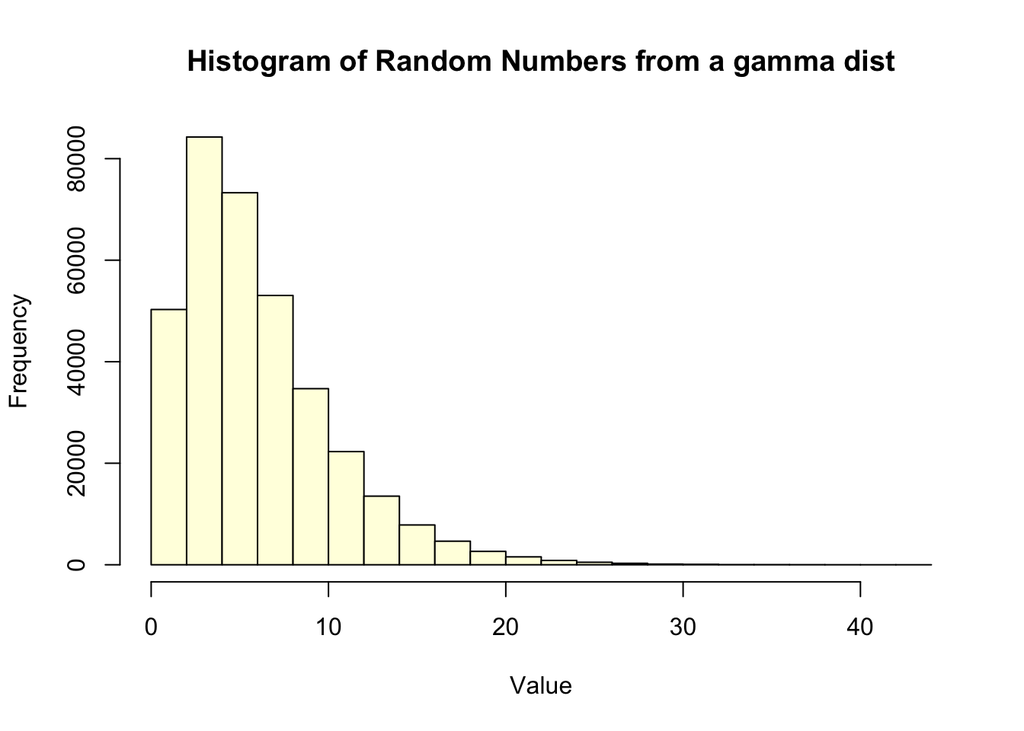

```r
# Set the seed for reproducibility
set.seed(911)

# Generate 350,000 random numbers from a gamma distribution
myVector <- rgamma(350000, shape = 2, scale = 3)

# Create a histogram
hist(myVector, main = "Histogram of Random Numbers from a gamma dist",
     xlab = "Value", ylab = "Frequency",
     col = "lightyellow", border = "black")
```

2. Convert `myVector` into a matrix with 5,000 rows and assign it to an object called `myMatrix`. **Report** the dimensions of `myMatrix`.
- **Answer**:

```r
# Create a matrix with 5,000 rows from myVector
myMatrix <- matrix(myVector, nrow = 5000)

# Report the dimensions of myMatrix
dim(myMatrix)
```

```
## [1] 5000   70
```

3. Compute the row means of `myMatrix` and **report** a histogram of those row means.
- **Answer**:

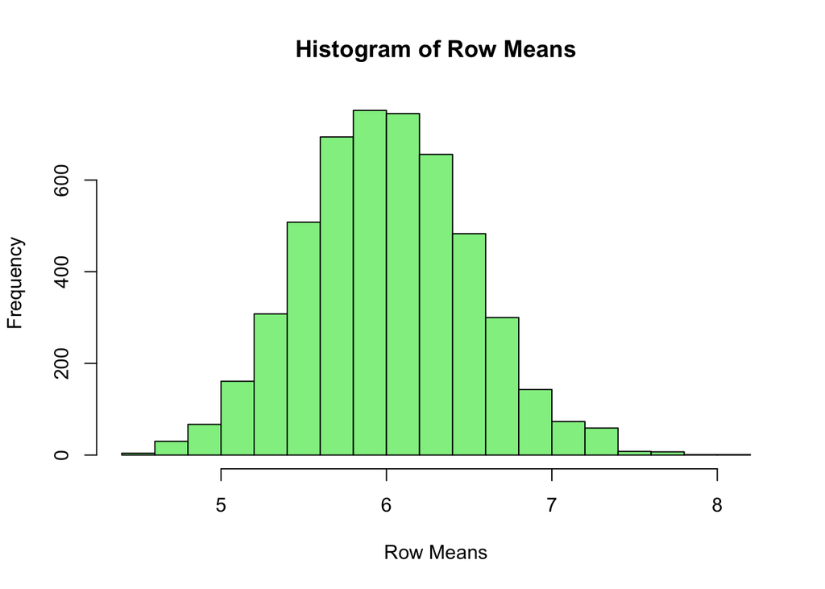

```r
# Compute row means of myMatrix
row_means <- rowMeans(myMatrix)

# Create a histogram of row means
hist(row_means, main = "Histogram of Row Means", xlab = "Row Means", ylab = "Frequency", col = "lightgreen")
```

```r
## Set the seed for reproducibility
set.seed(2019)
```

2. Create a vector called `x` of 1,000 values from a normal distribution with mean 100 and standard deviation 20. **Report** the `summary()` of `x`.
   - **Answer**:

```r
# Set the seed for reproducibility
set.seed(2019)

# Generate a vector of 1,000 values from a normal distribution
x <- rnorm(1000, mean = 100, sd = 20)

# Report the summary of x
summary(x)
```

```
##    Min. 1st Qu.  Median    Mean 3rd Qu.    Max.
##   35.28   85.45   97.36   98.44  111.97  170.83
```

3. Create a second vector called `y` of 1,000 values from a normal distribution with mean 0 and standard deviation 4. **Report** the `summary()` of `y`.
- **Answer**:

```r
# Set the seed for reproducibility
set.seed(2019)

# Generate a vector of 1,000 values from a normal distribution
y <- rnorm(1000, mean = 0, sd =4)

# Report the summary of x
summary(y)
```

```
##     Min.  1st Qu.   Median     Mean  3rd Qu.     Max.
## -12.9443  -2.9092  -0.5285  -0.3127   2.3943  14.1658
```

```r
# Create a data frame df from vectors x and y
df <- data.frame(x, y)
```

8. Generate a scatterplot of `df`.
- **Answer**:

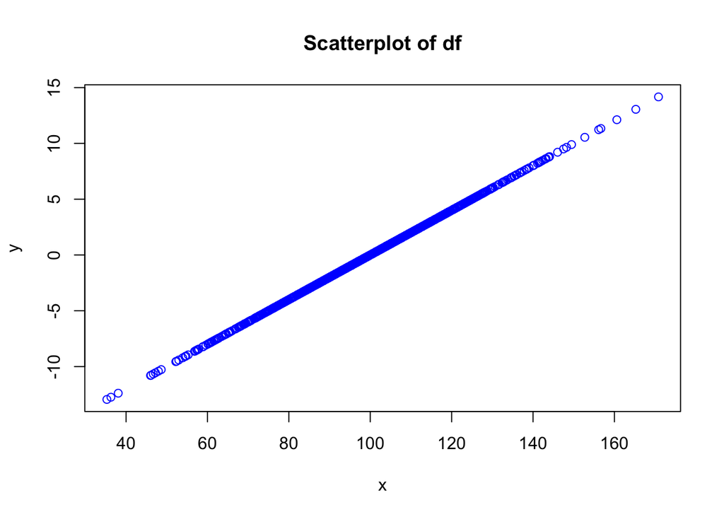

```r
# Generate a scatterplot of df
plot(df$x, df$y, main = "Scatterplot of df", xlab = "x", ylab = "y", col = "blue")
```

—

1. **Report** the `tail()` of `df` as a nice table using `kable()`.
- **Answer**:

```r
#install.packages("knitr")
library(knitr)

# Display the tail of df as a table
kable(tail(df),align = "lccc",caption = "Bottom data of DF",format = "markdown")
```

Bottom data of DF

|  | x | y |
| --- | --- | --- |
| 995 | 94.00851 | -1.198299 |
| 996 | 87.08630 | -2.582740 |
| 997 | 81.18893 | -3.762213 |
| 998 | 121.24816 | 4.249633 |
| 999 | 84.73008 | -3.053983 |
| 1000 | 119.20879 | 3.841757 |

8. Based on our lecture notes, answer the following questions. Show your answer presenting the relavent `R` code.
1. We have a vector of values `x = c(2,4,5, "3.5")`. What would be the mode of the vector `x`?
- **Answer**:The mode of the vector`x` is character

```r
x <- c(2, 4, 5, "3.5")
mode_x <- mode(x)
mode_x
```

```
## [1] "character"
```

2. How do you load a package into `R`? Show that loading `ggplot2` package. - **Answer**:

```r
library("ggplot2")
```

3. Missing values are shown as `NA` in `R`. How can you check if there is any missing values in a vector `y = c(3,5,8, NA, 6)`? - **Answer**:when my variable `missing_values` print `TRUE` then i will know.

```r
# Create a vector
y <- c(3, 5, 8, NA, 6)

# Check for missing values
missing_values <- is.na(y)
missing_values
```

```
## [1] FALSE FALSE FALSE  TRUE FALSE
```